# FinalProject5sem

Nika Vatolkina

18 12 2021

#подгрузка пакетов

```r
library(tidyverse)
library(rnaturalearth)
library(rnaturalearthdata)
```

```r
library(corrplot)
library(car)
library(reshape2)
library(pheatmap)
```

```r
library(reshape2)
```

```r
library(nnet)
```

```r
library(foreign)
```

#немного о датасете датасет содержит данные о местоположении покемонов 1 поколения в покемон го в каких-то местах в определённый период

```r
PoGo <- read.csv('./300k.csv')
```

столбцы: pokemonId - the identifier of a pokemon, should be deleted to not affect predictions. latitude, longitude - coordinates of a sighting appearedLocalTime - exact time of a sighting in - geographic position projected on a S2 Cell, with cell sizes ranging from 90 to 5850m (numeric) appearedTimeOfDay - time of the day of a sighting (night, evening, afternoon, morning) appearedHour/appearedMinute - local hour/minute of a sighting (numeric) appearedDayOfWeek - week day of a sighting (Monday, Tuesday, Wednesday, Thursday, Friday, Saturday, Sunday) appearedDay/appearedMonth/appearedYear - day/month/year of a sighting (numeric) terrainType - terrain where pokemon appeared described with help of GLCF Modis Land Cover (numeric) closeToWater - did pokemon appear close (100m or less) to water (Boolean, same source as above) city - the city of a sighting (nominal) continent (not always parsed right) - the continent of a sighting (nominal) weather - weather type during a sighting (Foggy Clear, PartlyCloudy, MostlyCloudy, Overcast, Rain, BreezyandOvercast, LightRain, Drizzle, BreezyandPartlyCloudy, HeavyRain, BreezyandMostlyCloudy, Breezy, Windy, WindyandFoggy, Humid, Dry, WindyandPartlyCloudy, DryandMostlyCloudy, DryandPartlyCloudy, DrizzleandBreezy, LightRainandBreezy, HumidandPartlyCloudy, HumidandOvercast, RainandWindy) // Source for all weather features temperature - temperature in celsius at the location of a sighting (numeric) windSpeed - speed of the wind in km/h at the location of a sighting (numeric) windBearing - wind direction (numeric) pressure - atmospheric pressure in bar at the location of a sighting (numeric) weatherIcon - a compact representation of the weather at the location of a sighting (fog, clear-night, partly-cloudy-night, partly-cloudy-day, cloudy, clear-day, rain, wind) sunriseMinutesMidnight-sunsetMinutesBefore - time of appearance relatively to sunrise/sunset Source population density - what is the population density per square km of a sighting (numeric, Source) urban-rural - how urban is location where pokemon appeared (Boolean, built on Population density, <200 for rural, >=200 and <400 for midUrban, >=400 and <800 for subUrban, >800 for urban) gymDistanceKm, pokestopDistanceKm - how far is the nearest gym/pokestop in km from a sighting? (numeric, extracted from this dataset) gymIn100m-pokestopIn5000m - is there a gym/pokestop in 100/200/etc meters? (Boolean) cooc 1-cooc 151 - co-occurrence with any other pokemon (pokemon ids range between 1 and 151) within 100m distance and within the last 24 hours (Boolean) class - says which pokemonId it is, to be predicted.

```r
head(PoGo)
```

```
##   pokemonId  latitude  longitude   appearedLocalTime
## 1        16  20.52575  -97.46083 2016-09-08T03:57:45
## 2       133  20.52370  -97.46117 2016-09-08T03:57:37
## 3        16  38.90359  -77.19978 2016-09-08T03:57:25
## 4        13  47.66590 -122.31256 2016-09-08T03:56:22
## 5       133  47.66645 -122.31163 2016-09-08T03:56:08
## 6        21 -31.95498  115.85361 2016-09-08T03:55:58
##                           X_id   cellId_90m  cellId_180m  cellId_370m
## 1 NTgxMDkzOTk4MTM5MjUwMjIzNw== 9.645139e+18 9.645139e+18 9.645139e+18
## 2 OTQ1NDgzODc1MjM3NDEzMTI2MQ== 9.645139e+18 9.645139e+18 9.645139e+18
## 3 NTQ0OTQ0NDA1Nzg2ODg3OTg2OQ== 9.923201e+18 9.923201e+18 9.923201e+18
## 4 NTU2MTU1NDM4NzA2MDk1MDcxNw== 6.093393e+18 6.093393e+18 6.093393e+18
## 5 MTY2ODg4MTAzMTczMDE0MTUwNTM= 6.093393e+18 6.093393e+18 6.093393e+18
## 6 MTA4NTIwMDE5MjEzOTQ0ODEzNDE= 3.040698e+18 3.040698e+18 3.040698e+18
##    cellId_730m cellId_1460m cellId_2920m cellId_5850m appearedTimeOfDay
```

[output cut: 188 more lines]

```r
dim(PoGo)
```

```
## [1] 296021    208
```

из всех столбцов мне интересны:

pokemonId - номер покемона в покедексе (numeric; ranges between 1 and 151)

weatherIcon - a compact representation of the weather at the location of a sighting (fog, clear-night, partly-cloudy-night, partly-cloudy-day, cloudy, clear-day, rain, wind)

cooc 1-cooc 151 - co-occurrence with any other pokemon (pokemon ids range between 1 and 151) within 100m distance and within the last 24 hours (Boolean)

pressure - atmospheric pressure in bar at the location of a sighting (numeric)

```r
sum(is.na(PoGo))
```

```
## [1] 0
```

все значения есть

##нормальность numeric данных

```r
windshp <- PoGo%>%
  slice_sample(n = 4999)
shapiro.test(windshp$appearedMinute)
```

```
##
##  Shapiro-Wilk normality test
##
## data:  windshp$appearedMinute
## W = 0.94966, p-value < 2.2e-16
```

```r
windshp <- PoGo%>%
  slice_sample(n = 4999)
shapiro.test(windshp$appearedHour)
```

```
##
##  Shapiro-Wilk normality test
##
## data:  windshp$appearedHour
## W = 0.94303, p-value < 2.2e-16
```

```r
windshp <- PoGo%>%
  slice_sample(n = 4999)
shapiro.test(windshp$appearedDay)
```

```
##
##  Shapiro-Wilk normality test
##
## data:  windshp$appearedDay
## W = 0.91733, p-value < 2.2e-16
```

```r
windshp <- PoGo%>%
  slice_sample(n = 4999)
shapiro.test(windshp$terrainType)
```

```
##
##  Shapiro-Wilk normality test
##
## data:  windshp$terrainType
## W = 0.73461, p-value < 2.2e-16
```

```r
windshp <- PoGo%>%
  slice_sample(n = 4999)
shapiro.test(windshp$temperature)
```

```
##
##  Shapiro-Wilk normality test
##
## data:  windshp$temperature
## W = 0.99088, p-value < 2.2e-16
```

```r
windshp <- PoGo%>%
  slice_sample(n = 4999)
shapiro.test(windshp$windSpeed)
```

```
##
##  Shapiro-Wilk normality test
##
## data:  windshp$windSpeed
## W = 0.90156, p-value < 2.2e-16
```

```r
windshp <- PoGo%>%
  slice_sample(n = 4999)
shapiro.test(windshp$windBearing)
```

```
##
##  Shapiro-Wilk normality test
##
## data:  windshp$windBearing
## W = 0.96029, p-value < 2.2e-16
```

```r
windshp <- PoGo%>%
  slice_sample(n = 4999)
shapiro.test(windshp$population_density)
```

```
##
##  Shapiro-Wilk normality test
##
## data:  windshp$population_density
## W = 0.65658, p-value < 2.2e-16
```

```r
windshp <- PoGo%>%
  slice_sample(n = 4999)
shapiro.test(windshp$gymDistanceKm)
```

```
##
##  Shapiro-Wilk normality test
##
## data:  windshp$gymDistanceKm
## W = 0.076675, p-value < 2.2e-16
```

```r
windshp <- PoGo%>%
  slice_sample(n = 4999)
shapiro.test(as.numeric(windshp$pokestopDistanceKm))
```

```
##
##  Shapiro-Wilk normality test
##
## data:  as.numeric(windshp$pokestopDistanceKm)
## W = 0.033033, p-value < 2.2e-16
```

В общем, нормальных данных тут нет ##где покемоны https://slcladal.github.io/maps.html#Generating_maps_with_rnaturalearth_and_ggplot2

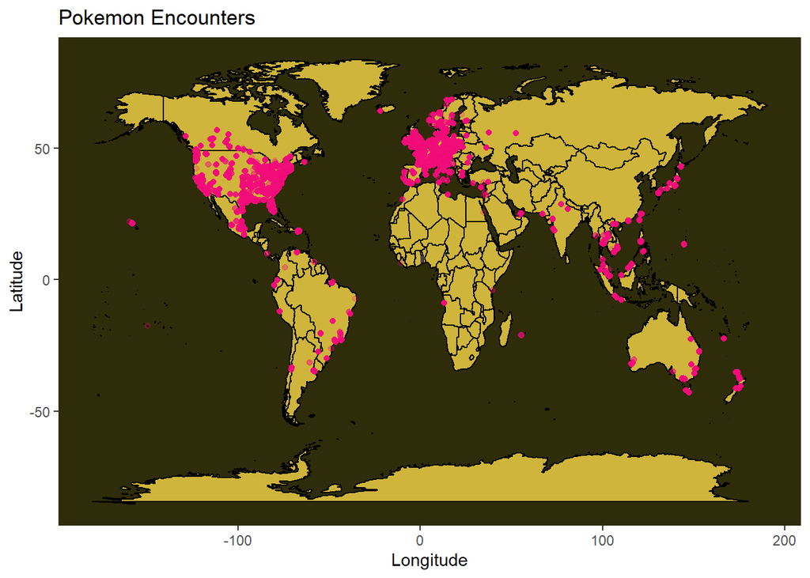

```r
world <- ne_countries(scale = "medium", returnclass = "sf")

ggplot(data = PoGo, aes(x = longitude, y = latitude)) +


  labs( x = "Longitude", y = "Latitude") +
  ggtitle("Pokemon Encounters")+

  borders("world", colour="black", fill="#cfb53b")+
  theme(panel.background = element_rect(fill ="#2f2c0a"),
        panel.grid.major = element_blank(),
        panel.grid.minor = element_blank())+

  geom_point(color="#f30b7b", alpha = .2)
```

##когда покемоны

```r
unique(PoGo$appearedYear)
```

```
## [1] 2016
```

```r
unique(PoGo$appearedMonth)
```

```
## [1] 8
```

```r
unique(PoGo$appearedDay)
```

```
## [1] 8 7 6 5 4 3 2
```

##гипотеза 1. как распределено появление покемонов по погоде(success)

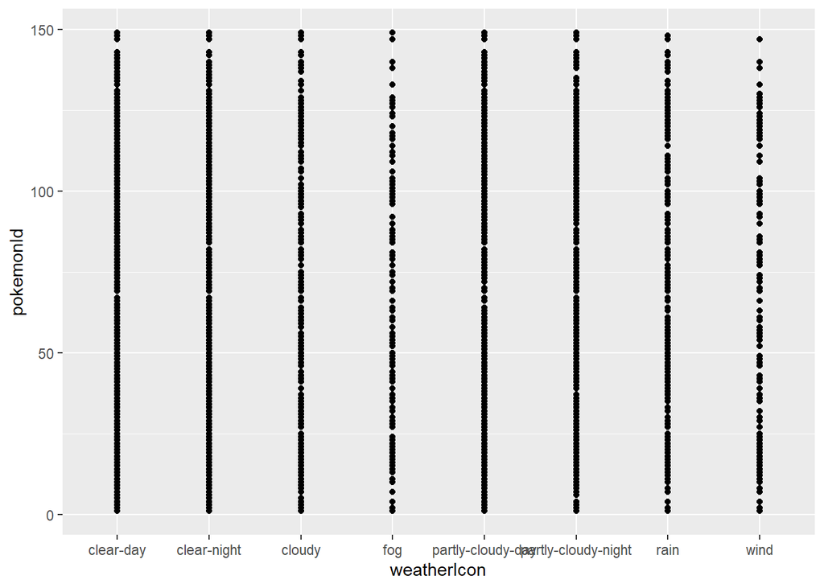

```r
ggplot(data = PoGo, aes(x = weatherIcon, y = pokemonId))+
  geom_point()
```

вообще в игре предполагается, что спавн покемонов зависит от погоды весьма сильно -_- я не хочу по этому графику строить лм

```r
g1 <- PoGo %>%
  group_by(weatherIcon)%>%
  summarise(n = n())
g1
```

```
## # A tibble: 8 x 2
##   weatherIcon             n
##   <chr>               <int>
## 1 clear-day           86955
## 2 clear-night         81346
## 3 cloudy              14868
## 4 fog                  1800
## 5 partly-cloudy-day   66808
## 6 partly-cloudy-night 30133
## 7 rain                11646
## 8 wind                 2465
```

теперь для каждой погоды можно посмотреть, какие покемоны там спавнятся и в каком количестве

```r
weather_and_poke <- PoGo%>%
  select(pokemonId, weatherIcon)
head(weather_and_poke)
```

```
##   pokemonId         weatherIcon
## 1        16                 fog
## 2       133                 fog
## 3        16         clear-night
## 4        13 partly-cloudy-night
## 5       133 partly-cloudy-night
## 6        21   partly-cloudy-day
```

```r
dim(weather_and_poke)
```

```
## [1] 296021      2
```

ещё мне хотелось бы добавить информацию о типе покемона, которой нет в датасете, потому что по игре как раз погода влияет на тип спауна, а от него номер покедекса должен зависеть. возьму инофрмацию из другого датасета - https://www.kaggle.com/maca11/all-pokemon-dataset

```r
all_poke <- read.csv("./All_Pokemon.csv")%>%
  rename(pokemonId = Number)%>%
  select(pokemonId, Type.1, Type.2, Name)%>%
  filter(pokemonId <= 151)%>%
  filter(!grepl("Mega ", Name))%>%
  filter(!grepl("Alolan", Name))%>%
  filter(!grepl("Galarian", Name))
head(all_poke)
```

```
##   pokemonId Type.1 Type.2       Name
## 1         1  Grass Poison  Bulbasaur
## 2         2  Grass Poison    Ivysaur
## 3         3  Grass Poison   Venusaur
## 4         4   Fire        Charmander
## 5         5   Fire        Charmeleon
## 6         6   Fire Flying  Charizard
```

```r
dim(all_poke)
```

```
## [1] 151   4
```

```r
weather_type <- merge(x = weather_and_poke, y = all_poke, by="pokemonId", all.x=TRUE)
head(weather_type)
```

```
##   pokemonId         weatherIcon Type.1 Type.2      Name
## 1         1   partly-cloudy-day  Grass Poison Bulbasaur
## 2         1                rain  Grass Poison Bulbasaur
## 3         1   partly-cloudy-day  Grass Poison Bulbasaur
## 4         1                wind  Grass Poison Bulbasaur
## 5         1                rain  Grass Poison Bulbasaur
## 6         1 partly-cloudy-night  Grass Poison Bulbasaur
```

```r
dim(weather_type)
```

```
## [1] 296021      5
```

```r
sum(is.null(weather_type$Type.2))
```

```
## [1] 0
```

```r
sum(is.na(weather_type$Type.2))
```

```
## [1] 0
```

0_o оно не работает. там же точно есть пропущенные значения, wtf

```r
sapply(X = weather_type, FUN = function(x) sum(is.na(x)))
```

```
##   pokemonId weatherIcon      Type.1      Type.2        Name
##           0           0           0           0           0
```

```r
map(weather_type, ~sum(is.na(.)))
```

```
## $pokemonId
## [1] 0
##
## $weatherIcon
## [1] 0
##
## $Type.1
## [1] 0
##
## $Type.2
## [1] 0
##
## $Name
## [1] 0
```

```r
weather_type[103103, 4]
```

```
## [1] ""
```

теперь мне всё ясно про составителей второго датасета.

```r
coalesc <- weather_type%>%
  mutate(Type.2 = coalesce(Type.2, Type.1))

head(coalesc)
```

```
##   pokemonId         weatherIcon Type.1 Type.2      Name
## 1         1   partly-cloudy-day  Grass Poison Bulbasaur
## 2         1                rain  Grass Poison Bulbasaur
## 3         1   partly-cloudy-day  Grass Poison Bulbasaur
## 4         1                wind  Grass Poison Bulbasaur
## 5         1                rain  Grass Poison Bulbasaur
## 6         1 partly-cloudy-night  Grass Poison Bulbasaur
```

это я сделала, чтобы покемоны с одинарным типом вносили такой же суммарно вклад, как и покемоны с двойным типом, но потом поняла, что это только портит.

```r
long_w_t <- weather_type %>%
  pivot_longer(cols = Type.1:Type.2, names_to = "nTypes", values_to = "Types")%>%
  filter(Types != '')
head(long_w_t)
```

```
## # A tibble: 6 x 5
##   pokemonId weatherIcon       Name      nTypes Types
##       <int> <chr>             <chr>     <chr>  <chr>
## 1         1 partly-cloudy-day Bulbasaur Type.1 Grass
## 2         1 partly-cloudy-day Bulbasaur Type.2 Poison
## 3         1 rain              Bulbasaur Type.1 Grass
## 4         1 rain              Bulbasaur Type.2 Poison
## 5         1 partly-cloudy-day Bulbasaur Type.1 Grass
## 6         1 partly-cloudy-day Bulbasaur Type.2 Poison
```

```r
dim(long_w_t)
```

```
## [1] 447232      5
```

```r
unique(long_w_t$Types)
```

```
##  [1] "Grass"    "Poison"   "Fire"     "Flying"   "Water"    "Bug"
##  [7] "Normal"   "Electric" "Ground"   "Fairy"    "Fighting" "Psychic"
## [13] "Rock"     "Steel"    "Ice"      "Ghost"    "Dragon"
```

```r
tabl <- table(long_w_t$weatherIcon, long_w_t$Types)
tabl
```

```
##
##                         Bug Dragon Electric Fairy Fighting  Fire Flying Ghost
##   clear-day           16509    195      879  1413      913  1493  23683   626
##   clear-night         15489    184      691  1396      948  1543  22003   625
##   cloudy               2870     26      237   280       75   107   4441   167
##   fog                   373      5       14    47        4    13    491    16
##   partly-cloudy-day   13830    154      598  1214      407   803  18510   697
##   partly-cloudy-night  5631     71      312   565      258   489   8110   318
##   rain                 2533     26       88   173       65   105   3252   109
##   wind                  406      3       84    31       12    45    600    18
##
##                       Grass Ground   Ice Normal Poison Psychic  Rock Steel
##   clear-day            5639   2664   201  37918  21784    4556  1462   333
##   clear-night          5699   2772   199  35134  20502    4354  1565   235
##   cloudy                687    162    59   6527   3649     904   122   112
##   fog                   171     20     4    687    569      93    10     7
##   partly-cloudy-day    3699   1173   212  27584  17559    4412   759   238
##   partly-cloudy-night  1796    881   123  11771   7789    2072   567   144
##   rain                  769    195    32   5255   3018     644   126    29
##   wind                  147     31     2    958    593     118    23    32
##
##                       Water
##   clear-day           10485
##   clear-night          9387
##   cloudy               2263
##   fog                   222
##   partly-cloudy-day    9692
##   partly-cloudy-night  4390
##   rain                 1450
##   wind                  519
```

```r
vectabl <- as.vector(tabl)
vectabl
```

```
##   [1] 16509 15489  2870   373 13830  5631  2533   406   195   184    26     5
##  [13]   154    71    26     3   879   691   237    14   598   312    88    84
##  [25]  1413  1396   280    47  1214   565   173    31   913   948    75     4
##  [37]   407   258    65    12  1493  1543   107    13   803   489   105    45
##  [49] 23683 22003  4441   491 18510  8110  3252   600   626   625   167    16
##  [61]   697   318   109    18  5639  5699   687   171  3699  1796   769   147
##  [73]  2664  2772   162    20  1173   881   195    31   201   199    59     4
##  [85]   212   123    32     2 37918 35134  6527   687 27584 11771  5255   958
##  [97] 21784 20502  3649   569 17559  7789  3018   593  4556  4354   904    93
## [109]  4412  2072   644   118  1462  1565   122    10   759   567   126    23
## [121]   333   235   112     7   238   144    29    32 10485  9387  2263   222
## [133]  9692  4390  1450   519
```

```r
mattabl <- matrix(data = vectabl, byrow = FALSE, nrow = 8)
mattabl
```

```
##       [,1] [,2] [,3] [,4] [,5] [,6]  [,7] [,8] [,9] [,10] [,11] [,12] [,13]
## [1,] 16509  195  879 1413  913 1493 23683  626 5639  2664   201 37918 21784
## [2,] 15489  184  691 1396  948 1543 22003  625 5699  2772   199 35134 20502
## [3,]  2870   26  237  280   75  107  4441  167  687   162    59  6527  3649
## [4,]   373    5   14   47    4   13   491   16  171    20     4   687   569
## [5,] 13830  154  598 1214  407  803 18510  697 3699  1173   212 27584 17559
## [6,]  5631   71  312  565  258  489  8110  318 1796   881   123 11771  7789
## [7,]  2533   26   88  173   65  105  3252  109  769   195    32  5255  3018
## [8,]   406    3   84   31   12   45   600   18  147    31     2   958   593
##      [,14] [,15] [,16] [,17]
## [1,]  4556  1462   333 10485
## [2,]  4354  1565   235  9387
## [3,]   904   122   112  2263
## [4,]    93    10     7   222
## [5,]  4412   759   238  9692
## [6,]  2072   567   144  4390
## [7,]   644   126    29  1450
## [8,]   118    23    32   519
```

```r
colnms <- c("Bug", "Dragon", "Electric", "Fairy", "Fighting",  "Fire", "Flying", "Ghost","Grass", "Ground",   "Ice", "Normal", "Poison", "Psychic",  "Rock", "Steel", "Water")
rownms <- c("clear-day", "clear-night", "cloudy", "fog", "partly-cloudy-day", "partly-cloudy-night", "rain", "wind")
rownames(mattabl) <- rownms
colnames(mattabl) <- colnms
mattabl
```

```
##                       Bug Dragon Electric Fairy Fighting Fire Flying Ghost
## clear-day           16509    195      879  1413      913 1493  23683   626
## clear-night         15489    184      691  1396      948 1543  22003   625
## cloudy               2870     26      237   280       75  107   4441   167
## fog                   373      5       14    47        4   13    491    16
## partly-cloudy-day   13830    154      598  1214      407  803  18510   697
## partly-cloudy-night  5631     71      312   565      258  489   8110   318
## rain                 2533     26       88   173       65  105   3252   109
## wind                  406      3       84    31       12   45    600    18
##                     Grass Ground Ice Normal Poison Psychic Rock Steel Water
## clear-day            5639   2664 201  37918  21784    4556 1462   333 10485
## clear-night          5699   2772 199  35134  20502    4354 1565   235  9387
## cloudy                687    162  59   6527   3649     904  122   112  2263
## fog                   171     20   4    687    569      93   10     7   222
## partly-cloudy-day    3699   1173 212  27584  17559    4412  759   238  9692
## partly-cloudy-night  1796    881 123  11771   7789    2072  567   144  4390
## rain                  769    195  32   5255   3018     644  126    29  1450
## wind                  147     31   2    958    593     118   23    32   519
```

```r
dftabl <- as.data.frame(mattabl)
dftabl
```

```
##                       Bug Dragon Electric Fairy Fighting Fire Flying Ghost
## clear-day           16509    195      879  1413      913 1493  23683   626
## clear-night         15489    184      691  1396      948 1543  22003   625
## cloudy               2870     26      237   280       75  107   4441   167
## fog                   373      5       14    47        4   13    491    16
## partly-cloudy-day   13830    154      598  1214      407  803  18510   697
## partly-cloudy-night  5631     71      312   565      258  489   8110   318
## rain                 2533     26       88   173       65  105   3252   109
## wind                  406      3       84    31       12   45    600    18
##                     Grass Ground Ice Normal Poison Psychic Rock Steel Water
## clear-day            5639   2664 201  37918  21784    4556 1462   333 10485
## clear-night          5699   2772 199  35134  20502    4354 1565   235  9387
## cloudy                687    162  59   6527   3649     904  122   112  2263
## fog                   171     20   4    687    569      93   10     7   222
## partly-cloudy-day    3699   1173 212  27584  17559    4412  759   238  9692
## partly-cloudy-night  1796    881 123  11771   7789    2072  567   144  4390
## rain                  769    195  32   5255   3018     644  126    29  1450
## wind                  147     31   2    958    593     118   23    32   519
```

```r
as.numeric(as.vector(dftabl[1,]))
```

```
##  [1] 16509   195   879  1413   913  1493 23683   626  5639  2664   201 37918
## [13] 21784  4556  1462   333 10485
```

```r
ks.test(as.numeric(as.vector(dftabl[1,])), as.numeric(as.vector(dftabl[2,])))
```

```
##
##  Two-sample Kolmogorov-Smirnov test
##
## data:  as.numeric(as.vector(dftabl[1, ])) and as.numeric(as.vector(dftabl[2, ]))
## D = 0.11765, p-value = 0.9999
## alternative hypothesis: two-sided
```

```r
exitmatrix <- matrix(, nrow = 8, ncol = 8)
rownames(exitmatrix) <- rownms
colnames(exitmatrix) <- rownms
```

```r
for(i in 1:8){
  for(j in 1:8){
    exitmatrix[i, j] <- ks.test(as.numeric(as.vector(dftabl[i,])), as.numeric(as.vector(dftabl[j,])),exact=FALSE)$p.value
  }
}
```

[output not shown]

[output cut: 96 more lines]

[output not shown]

```r
exitmatrix
```

```
##                        clear-day  clear-night     cloudy          fog
## clear-day           1.000000e+00 9.997960e-01 0.04634828 9.630125e-05
## clear-night         9.997960e-01 1.000000e+00 0.04634828 9.630125e-05
## cloudy              4.634828e-02 4.634828e-02 1.00000000 1.705078e-02
## fog                 9.630125e-05 9.630125e-05 0.01705078 1.000000e+00
## partly-cloudy-day   7.344067e-01 7.344067e-01 0.11198600 4.190832e-04
## partly-cloudy-night 2.402097e-01 2.402097e-01 0.24020970 5.576434e-03
## rain                1.705078e-02 1.705078e-02 0.95390911 1.705078e-02
## wind                9.630125e-05 9.630125e-05 0.04634828 4.540085e-01
##                     partly-cloudy-day partly-cloudy-night       rain
## clear-day                0.7344067391         0.240209704 0.01705078
## clear-night              0.7344067391         0.240209704 0.01705078
## cloudy                   0.1119859996         0.240209704 0.95390911
## fog                      0.0004190832         0.005576434 0.01705078
## partly-cloudy-day        1.0000000000         0.454008497 0.01705078
## partly-cloudy-night      0.4540084967         1.000000000 0.11198600
## rain                     0.0170507801         0.111986000 1.00000000
## wind                     0.0004190832         0.005576434 0.24020970
##                             wind
## clear-day           9.630125e-05
## clear-night         9.630125e-05
## cloudy              4.634828e-02
## fog                 4.540085e-01
## partly-cloudy-day   4.190832e-04
## partly-cloudy-night 5.576434e-03
## rain                2.402097e-01
## wind                1.000000e+00
```

```r
as.numeric(exitmatrix)
```

```
##  [1] 1.000000e+00 9.997960e-01 4.634828e-02 9.630125e-05 7.344067e-01
##  [6] 2.402097e-01 1.705078e-02 9.630125e-05 9.997960e-01 1.000000e+00
## [11] 4.634828e-02 9.630125e-05 7.344067e-01 2.402097e-01 1.705078e-02
## [16] 9.630125e-05 4.634828e-02 4.634828e-02 1.000000e+00 1.705078e-02
## [21] 1.119860e-01 2.402097e-01 9.539091e-01 4.634828e-02 9.630125e-05
## [26] 9.630125e-05 1.705078e-02 1.000000e+00 4.190832e-04 5.576434e-03
## [31] 1.705078e-02 4.540085e-01 7.344067e-01 7.344067e-01 1.119860e-01
## [36] 4.190832e-04 1.000000e+00 4.540085e-01 1.705078e-02 4.190832e-04
## [41] 2.402097e-01 2.402097e-01 2.402097e-01 5.576434e-03 4.540085e-01
## [46] 1.000000e+00 1.119860e-01 5.576434e-03 1.705078e-02 1.705078e-02
## [51] 9.539091e-01 1.705078e-02 1.705078e-02 1.119860e-01 1.000000e+00
## [56] 2.402097e-01 9.630125e-05 9.630125e-05 4.634828e-02 4.540085e-01
## [61] 4.190832e-04 5.576434e-03 2.402097e-01 1.000000e+00
```

```r
adj_pvals <- p.adjust(as.numeric(exitmatrix), method = 'holm')
adj_pvals
```

```
##  [1] 1.00000000 1.00000000 1.00000000 0.00616328 1.00000000 1.00000000
##  [7] 0.81843745 0.00616328 1.00000000 1.00000000 1.00000000 0.00616328
## [13] 1.00000000 1.00000000 0.81843745 0.00616328 1.00000000 1.00000000
## [19] 1.00000000 0.81843745 1.00000000 1.00000000 1.00000000 1.00000000
## [25] 0.00616328 0.00616328 0.81843745 1.00000000 0.02346866 0.28997457
## [31] 0.81843745 1.00000000 1.00000000 1.00000000 1.00000000 0.02346866
## [37] 1.00000000 1.00000000 0.81843745 0.02346866 1.00000000 1.00000000
## [43] 1.00000000 0.28997457 1.00000000 1.00000000 1.00000000 0.28997457
## [49] 0.81843745 0.81843745 1.00000000 0.81843745 0.81843745 1.00000000
## [55] 1.00000000 1.00000000 0.00616328 0.00616328 1.00000000 1.00000000
## [61] 0.02346866 0.28997457 1.00000000 1.00000000
```

```r
adjmat <- matrix(data = adj_pvals, byrow = FALSE, nrow = 8)
rownames(adjmat) <- rownms
colnames(adjmat) <- rownms
adjmat
```

```
##                      clear-day clear-night    cloudy        fog
## clear-day           1.00000000  1.00000000 1.0000000 0.00616328
## clear-night         1.00000000  1.00000000 1.0000000 0.00616328
## cloudy              1.00000000  1.00000000 1.0000000 0.81843745
## fog                 0.00616328  0.00616328 0.8184374 1.00000000
## partly-cloudy-day   1.00000000  1.00000000 1.0000000 0.02346866
## partly-cloudy-night 1.00000000  1.00000000 1.0000000 0.28997457
## rain                0.81843745  0.81843745 1.0000000 0.81843745
## wind                0.00616328  0.00616328 1.0000000 1.00000000
##                     partly-cloudy-day partly-cloudy-night      rain       wind
## clear-day                  1.00000000           1.0000000 0.8184374 0.00616328
## clear-night                1.00000000           1.0000000 0.8184374 0.00616328
## cloudy                     1.00000000           1.0000000 1.0000000 1.00000000
## fog                        0.02346866           0.2899746 0.8184374 1.00000000
## partly-cloudy-day          1.00000000           1.0000000 0.8184374 0.02346866
## partly-cloudy-night        1.00000000           1.0000000 1.0000000 0.28997457
## rain                       0.81843745           1.0000000 1.0000000 1.00000000
## wind                       0.02346866           0.2899746 1.0000000 1.00000000
```

```r
adjexitdf <- as.data.frame(adjmat)
adjexitdf
```

```
##                      clear-day clear-night    cloudy        fog
## clear-day           1.00000000  1.00000000 1.0000000 0.00616328
## clear-night         1.00000000  1.00000000 1.0000000 0.00616328
## cloudy              1.00000000  1.00000000 1.0000000 0.81843745
## fog                 0.00616328  0.00616328 0.8184374 1.00000000
## partly-cloudy-day   1.00000000  1.00000000 1.0000000 0.02346866
## partly-cloudy-night 1.00000000  1.00000000 1.0000000 0.28997457
## rain                0.81843745  0.81843745 1.0000000 0.81843745
## wind                0.00616328  0.00616328 1.0000000 1.00000000
##                     partly-cloudy-day partly-cloudy-night      rain       wind
## clear-day                  1.00000000           1.0000000 0.8184374 0.00616328
## clear-night                1.00000000           1.0000000 0.8184374 0.00616328
## cloudy                     1.00000000           1.0000000 1.0000000 1.00000000
## fog                        0.02346866           0.2899746 0.8184374 1.00000000
## partly-cloudy-day          1.00000000           1.0000000 0.8184374 0.02346866
## partly-cloudy-night        1.00000000           1.0000000 1.0000000 0.28997457
## rain                       0.81843745           1.0000000 1.0000000 1.00000000
## wind                       0.02346866           0.2899746 1.0000000 1.00000000
```

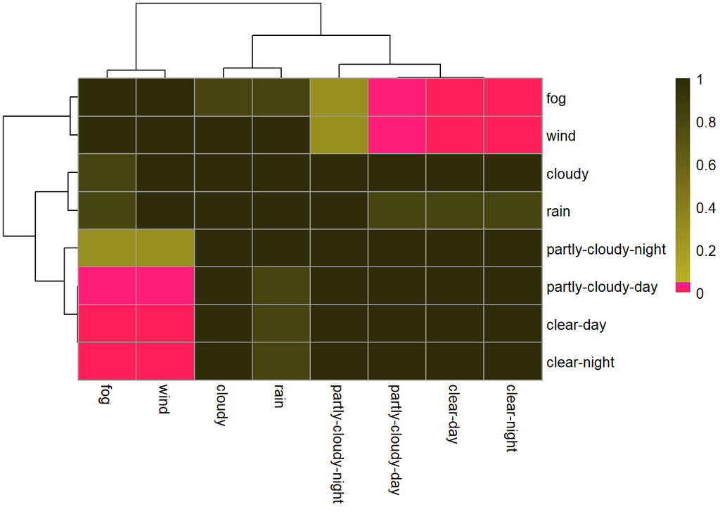

```r
bk1 <- c(seq(0, 0.049, by = 0.001))
bk2 <- c(seq(0.05, 1, by = 0.01))
bk <- c(bk1, bk2)


my_palette <- c(colorRampPalette(colors = c("#ff204e", "#fe1aa4"))(n = length(bk1)-1),
              c(colorRampPalette(colors = c("#bcb227","#2f2c0a" ))(n = length(bk2)-1)))



pheatmap(adjmat, cluster_cols = TRUE, cluster_rows = TRUE, color = my_palette, breaks = bk)
```

В основном выборки приходят из одинаковых распределений. почему эти 3*2 так себя ведут даже после поправки на множественное тестирование - сказать не могу. Есть только предположение, что распределения покетипов на каждую погоду так слабо отличаются между собой, что в большинстве случаев даже на такой большой выборке ks.test не видит разницы, а в тех, что отличаются сильнее всех, что-то находит.

##гипотеза 2. влияют ли другие покемоны линейно на появление нового покемона? (failed)

```r
g2 <- PoGo%>%
  select(pokemonId, starts_with("cooc"))
head(g2)
```

```
##   pokemonId cooc_1 cooc_2 cooc_3 cooc_4 cooc_5 cooc_6 cooc_7 cooc_8 cooc_9
## 1        16   true  false  false  false  false  false  false  false  false
## 2       133  false  false  false  false  false  false  false  false  false
## 3        16  false  false  false  false  false  false  false  false  false
## 4        13  false  false  false  false  false  false  false  false  false
## 5       133  false  false  false  false  false  false  false  false  false
## 6        21  false  false  false  false  false  false  false  false  false
##   cooc_10 cooc_11 cooc_12 cooc_13 cooc_14 cooc_15 cooc_16 cooc_17 cooc_18
## 1   false   false   false   false   false   false   false   false   false
## 2   false   false   false    true   false   false   false   false   false
## 3   false   false   false    true   false   false   false   false   false
## 4   false   false   false   false   false   false   false   false   false
## 5   false   false   false   false   false   false   false   false   false
## 6   false   false   false   false   false   false   false   false   false
##   cooc_19 cooc_20 cooc_21 cooc_22 cooc_23 cooc_24 cooc_25 cooc_26 cooc_27
```

[output cut: 111 more lines]

переведём булевые данные в 0/1:

```r
gg2 <- g2%>%
  mutate(across(where(is.character), as.logical))%>%
  mutate(across(where(is.logical), as.numeric))

head(gg2)
```

```
##   pokemonId cooc_1 cooc_2 cooc_3 cooc_4 cooc_5 cooc_6 cooc_7 cooc_8 cooc_9
## 1        16      1      0      0      0      0      0      0      0      0
## 2       133      0      0      0      0      0      0      0      0      0
## 3        16      0      0      0      0      0      0      0      0      0
## 4        13      0      0      0      0      0      0      0      0      0
## 5       133      0      0      0      0      0      0      0      0      0
## 6        21      0      0      0      0      0      0      0      0      0
##   cooc_10 cooc_11 cooc_12 cooc_13 cooc_14 cooc_15 cooc_16 cooc_17 cooc_18
## 1       0       0       0       0       0       0       0       0       0
## 2       0       0       0       1       0       0       0       0       0
## 3       0       0       0       1       0       0       0       0       0
## 4       0       0       0       0       0       0       0       0       0
## 5       0       0       0       0       0       0       0       0       0
## 6       0       0       0       0       0       0       0       0       0
##   cooc_19 cooc_20 cooc_21 cooc_22 cooc_23 cooc_24 cooc_25 cooc_26 cooc_27
```

[output cut: 111 more lines]

```r
correl <- cor(gg2)
```

выведу в отдельный файл, чтобы в отдельном окне открывать и смотреть без рерана всех чанков

```r
png("Plot3.png", width = 4, height = 4, units = 'in', res = 900)
corrplot(correl, method = 'color', number.cex=0.75, tl.cex=0.2)
dev.off()
```

и вот отдельно картиночка:

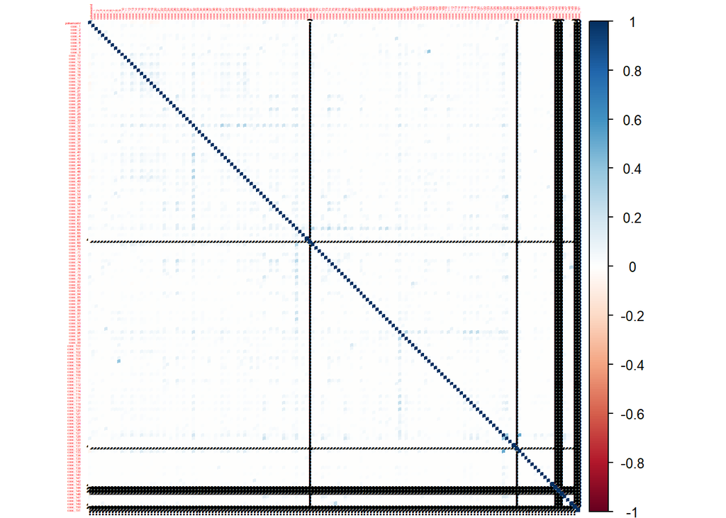

```r
corrplot(correl, method = 'color', number.cex=0.75, tl.cex=0.2)
```

посмотрим, какие корреляции оказались >0.5 по модулю

```r
corr <- cor(gg2)
corr[lower.tri(corr,diag=TRUE)] <- NA

corr[corr == 1] <- NA

corr <- as.data.frame(as.table(corr))

corr <- na.omit(corr)


corr <- subset(corr, abs(Freq) > 0.5)

corr <- corr[order(-abs(corr$Freq)),]

corr
```

```
##           Var1     Var2     Freq
## 20345 cooc_128 cooc_133 0.501714
```

в целом, можно сказать, что мультиколлинеарность отсутствует

```r
model <- lm(pokemonId ~., data = gg2)
summary(model)
```

```
##
## Call:
## lm(formula = pokemonId ~ ., data = gg2)
##
## Residuals:
##     Min      1Q  Median      3Q     Max
## -137.92  -28.32  -20.52   19.05  114.72
##
## Coefficients: (7 not defined because of singularities)
##              Estimate Std. Error t value Pr(>|t|)
## (Intercept)  44.31646    0.08887 498.641  < 2e-16 ***
## cooc_1        2.99764    0.93680   3.200 0.001375 **
## cooc_2        4.53189    2.99250   1.514 0.129922
## cooc_3       13.16395   10.41753   1.264 0.206362
## cooc_4       -1.01451    1.40733  -0.721 0.470987
## cooc_5       -3.25658    5.30717  -0.614 0.539468
## cooc_6       -6.77045   11.74034  -0.577 0.564154
## cooc_7        4.13180    0.89593   4.612 3.99e-06 ***
## cooc_8       12.93961    3.13203   4.131 3.61e-05 ***
## cooc_9        1.11671    7.63078   0.146 0.883651
## cooc_10      -0.43329    0.36921  -1.174 0.240570
## cooc_11      -0.26319    1.32802  -0.198 0.842902
## cooc_12      -0.63384    3.38676  -0.187 0.851540
## cooc_13      -1.47664    0.26704  -5.530 3.21e-08 ***
## cooc_14      -4.55116    0.83151  -5.473 4.42e-08 ***
## cooc_15      -1.96410    2.45430  -0.800 0.423556
## cooc_16       0.73944    0.22031   3.356 0.000790 ***
## cooc_17      -5.46023    0.60554  -9.017  < 2e-16 ***
## cooc_18      -3.24473    1.58829  -2.043 0.041063 *
## cooc_19      -3.98418    0.24737 -16.106  < 2e-16 ***
## cooc_20      -7.57301    0.96853  -7.819 5.34e-15 ***
## cooc_21      -4.79187    0.35605 -13.458  < 2e-16 ***
## cooc_22      -7.94093    1.77818  -4.466 7.98e-06 ***
## cooc_23       3.03797    0.56428   5.384 7.30e-08 ***
## cooc_24      -1.43208    2.63177  -0.544 0.586338
## cooc_25      -0.52118    1.68443  -0.309 0.757009
## cooc_26       8.68354   19.42908   0.447 0.654922
## cooc_27       4.64742    0.78563   5.916 3.31e-09 ***
## cooc_28       4.74740    3.67413   1.292 0.196318
## cooc_29       2.14189    0.57011   3.757 0.000172 ***
```

[output cut: 113 more lines]

```
## cooc_143     -2.20075    3.34990  -0.657 0.511206
## cooc_144           NA         NA      NA       NA
## cooc_145           NA         NA      NA       NA
## cooc_146           NA         NA      NA       NA
## cooc_147     16.55504    1.40426  11.789  < 2e-16 ***
## cooc_148     29.30431    4.59110   6.383 1.74e-10 ***
## cooc_149     -5.52348    5.46838  -1.010 0.312460
## cooc_150           NA         NA      NA       NA
## cooc_151           NA         NA      NA       NA
## ---
## Signif. codes:  0 '***' 0.001 '**' 0.01 '*' 0.05 '.' 0.1 ' ' 1
##
## Residual standard error: 38.86 on 295876 degrees of freedom
## Multiple R-squared:  0.03779,    Adjusted R-squared:  0.03733
## F-statistic: 80.71 on 144 and 295876 DF,  p-value: < 2.2e-16
```

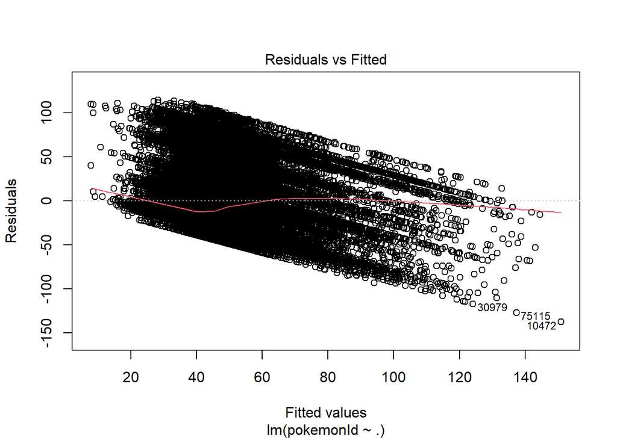

```r
plot(model, 1)
```

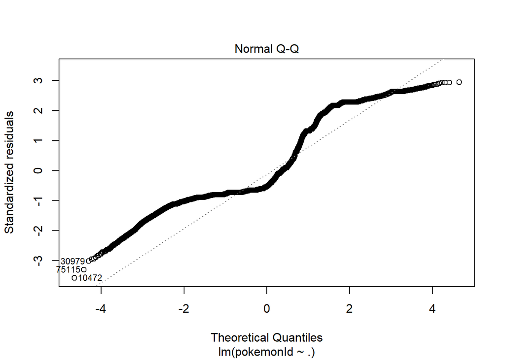

```r
plot(model, 2)
```

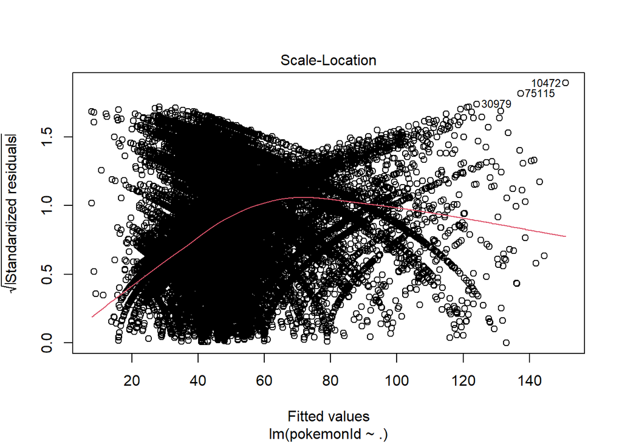

```r
plot(model, 3)
```

предположения линейной регрессии не соблюдены

##гипотеза 3. Зависимость появления покемонов от давления. давление - самый неожиданный для меня параметр, мне стало интересно посмотреть, зависит ли от него хоть что-нибудь (покемон = его тип)

```r
pres <- PoGo%>%
  select(pokemonId, pressure)
head(pres)
```

```
##   pokemonId pressure
## 1        16  1018.02
## 2       133  1018.02
## 3        16  1015.29
## 4        13  1020.52
## 5       133  1020.52
## 6        21  1024.44
```

```r
press_type <- merge(x = pres, y = all_poke, by="pokemonId", all.x=TRUE)
head(weather_type)
```

```
##   pokemonId         weatherIcon Type.1 Type.2      Name
## 1         1   partly-cloudy-day  Grass Poison Bulbasaur
## 2         1                rain  Grass Poison Bulbasaur
## 3         1   partly-cloudy-day  Grass Poison Bulbasaur
## 4         1                wind  Grass Poison Bulbasaur
## 5         1                rain  Grass Poison Bulbasaur
## 6         1 partly-cloudy-night  Grass Poison Bulbasaur
```

```r
dim(weather_type)
```

```
## [1] 296021      5
```

```r
long_p_t <- press_type %>%
  pivot_longer(cols = Type.1:Type.2, names_to = "nTypes", values_to = "Types")%>%
  filter(Types != '')
head(long_p_t)
```

```
## # A tibble: 6 x 5
##   pokemonId pressure Name      nTypes Types
##       <int>    <dbl> <chr>     <chr>  <chr>
## 1         1    1017. Bulbasaur Type.1 Grass
## 2         1    1017. Bulbasaur Type.2 Poison
## 3         1    1017. Bulbasaur Type.1 Grass
## 4         1    1017. Bulbasaur Type.2 Poison
## 5         1    1009. Bulbasaur Type.1 Grass
## 6         1    1009. Bulbasaur Type.2 Poison
```

```r
dim(long_p_t)
```

```
## [1] 447232      5
```

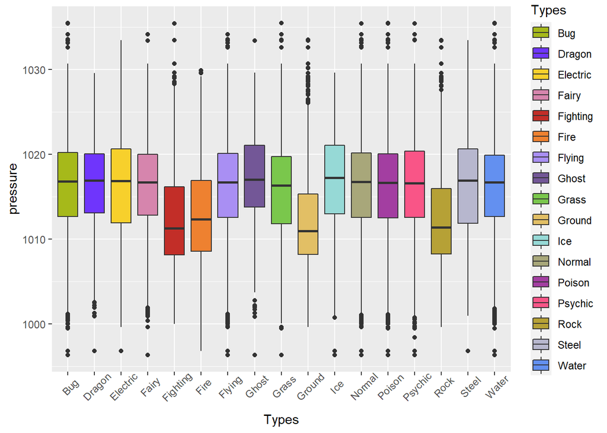

```r
ggplot(data = long_p_t, aes(x = Types, y = pressure, fill = Types))+
  geom_boxplot()+
  theme(axis.text.x = element_text(angle = 45, vjust = 0.8))+
  scale_fill_manual(values = c(
    '#A6B91A', #bug:
    '#6F35FC', #dragon:
    '#F7D02C', #electric:
    '#D685AD', #fairy:
    '#C22E28', #fighting:
    '#EE8130', #fire:
    '#A98FF3', #flying:
    '#735797', #ghost:
    '#7AC74C', #grass:
    '#E2BF65', #ground:
    '#96D9D6', #ice:
    '#A8A77A', #normal:
    '#A33EA1', #poison:
    '#F95587', #psychic:
    '#B6A136', #rock:
    '#B7B7CE', #steel:
    '#6390F0' #water: ##dark: '#705746'
  ))
```

общие данные по давлению распределены ненормально, но что про данные в рамках одной категории?

```r
grass <- long_p_t%>%
  filter(Types=='Grass')%>%
  slice_sample(n = 4999)
shapiro.test(grass$pressure)
```

```
##
##  Shapiro-Wilk normality test
##
## data:  grass$pressure
## W = 0.99387, p-value = 8.3e-14
```

и для хотя бы одной категории распределены ненормально -> без ановы сегодня :(

выход есть - (мульти)номинальная регрессия: https://stats.oarc.ucla.edu/r/dae/multinomial-logistic-regression/

```r
mean(long_p_t$pressure)
```

```
## [1] 1016.177
```

у grass среднее ближе всего к нему, поэтому буду равняться на него

```r
long_p_t$prog <- relevel(factor(long_p_t$Types), ref = 'Grass')
head(long_p_t)
```

```
## # A tibble: 6 x 6
##   pokemonId pressure Name      nTypes Types  prog
##       <int>    <dbl> <chr>     <chr>  <chr>  <fct>
## 1         1    1017. Bulbasaur Type.1 Grass  Grass
## 2         1    1017. Bulbasaur Type.2 Poison Poison
## 3         1    1017. Bulbasaur Type.1 Grass  Grass
## 4         1    1017. Bulbasaur Type.2 Poison Poison
## 5         1    1009. Bulbasaur Type.1 Grass  Grass
## 6         1    1009. Bulbasaur Type.2 Poison Poison
```

```r
test <- multinom(prog~pressure, data = long_p_t)
sum <- summary(test)
sum
```

```
## Call:
## multinom(formula = prog ~ pressure, data = long_p_t)
##
## Coefficients:
##            (Intercept)      pressure
## Bug       9.109622e-07  1.113100e-03
## Dragon   -3.229228e-06 -3.278707e-03
## Electric -1.801980e-06 -1.827104e-03
## Fairy    -1.276564e-06 -1.269219e-03
## Fighting -1.754326e-06 -1.909088e-03
## Fire     -1.176449e-06 -1.378975e-03
## Flying    1.232862e-06  1.449069e-03
## Ghost    -1.946380e-06 -1.943726e-03
## Ground   -4.252149e-07 -8.472197e-04
## Ice      -3.017643e-06 -3.057028e-03
## Normal    1.575907e-06  1.881403e-03
## Poison    1.223066e-06  1.378553e-03
## Psychic  -1.289906e-07 -7.949554e-05
## Rock     -1.127946e-06 -1.372169e-03
## Steel    -2.712998e-06 -2.756257e-03
## Water     6.085887e-07  7.138755e-04
##
## Std. Errors:
##           (Intercept)     pressure
## Bug      8.165760e-09 8.298430e-06
## Dragon   3.823270e-08 3.884708e-05
## Electric 1.932022e-08 1.963159e-05
## Fairy    1.528274e-08 1.552931e-05
## Fighting 2.003299e-08 2.035579e-05
## Fire     1.597409e-08 1.623177e-05
## Flying   7.872165e-09 8.000309e-06
## Ghost    2.034433e-08 2.067213e-05
## Ground   1.302660e-08 1.323697e-05
## Ice      3.430869e-08 3.486026e-05
## Normal   7.606218e-09 7.730440e-06
## Poison   7.926583e-09 8.055556e-06
## Psychic  1.025097e-08 1.041681e-05
## Rock     1.592986e-08 1.618682e-05
## Steel    2.967130e-08 3.014860e-05
## Water    8.650017e-09 8.790309e-06
##
## Residual Deviance: 1829050
## AIC: 1829114
```

```r
z <- sum$coefficients/sum$standard.errors
z
```

```
##          (Intercept)   pressure
## Bug        111.55879 134.133812
## Dragon     -84.46248 -84.400347
## Electric   -93.26910 -93.069591
## Fairy      -83.52980 -81.730552
## Fighting   -87.57182 -93.786007
## Fire       -73.64729 -84.955323
## Flying     156.61034 181.126587
## Ghost      -95.67184 -94.026402
## Ground     -32.64204 -64.004068
## Ice        -87.95564 -87.693783
## Normal     207.18663 243.375896
## Poison     154.29923 171.130652
## Psychic    -12.58326  -7.631468
## Rock       -70.80700 -84.770752
## Steel      -91.43510 -91.422415
## Water       70.35694  81.211653
```

```r
p <- (1 - pnorm(abs(z), 0, 1)) * 2
p
```

```
##          (Intercept)     pressure
## Bug                0 0.000000e+00
## Dragon             0 0.000000e+00
## Electric           0 0.000000e+00
## Fairy              0 0.000000e+00
## Fighting           0 0.000000e+00
## Fire               0 0.000000e+00
## Flying             0 0.000000e+00
## Ghost              0 0.000000e+00
## Ground             0 0.000000e+00
## Ice                0 0.000000e+00
## Normal             0 0.000000e+00
## Poison             0 0.000000e+00
## Psychic            0 2.331468e-14
## Rock               0 0.000000e+00
## Steel              0 0.000000e+00
## Water              0 0.000000e+00
```